# Extensions to the Grammar of Graphics

Data labels are not annotations

Pedro J. Aphalo

2021-04-04

## Preliminaries

We load all the packages used in the examples.

```r
library(ggpmisc)
library(ggrepel)
library(tibble)
library(dplyr)
```

As we will use text and labels on the plotting area we change the default theme to an uncluttered one.

```r
old_theme <- theme_set(theme_bw())
```

# Introduction to the extensions

## Data labels, annotations and insets

*Data labels* add textual information directly related to individual data points (shown as glyphs). Text position in this case is dependent on the scales used to represent data points. Text is usually displaced so that it does not occlude the glyph representing the data point and when the link to the data point is unclear, this link is signaled with a line segment or arrow. Data labels are distinct from annotations but instead contribute to the representation of data on a plot or map.

*References* are lines, shading or marks used to help the reading of a plot. These elements are used to highlight specific values on an axis or a region in a plot. They, like data labels, are positioned relative to the scales used for data. The position of data labels and lines, glyphs or shading used as reference cannot be altered by the designer of a plot, as the position conveys information. I will use the term *data labels* irrespective if the “labels” are textual or graphical, like icons and small plots and simple tables linked to data points or map features.

According to Koponen and Hildén (2019), “[in a statistical chart] annotations can be used to draw reader attention to relevant detail”. These authors use as an example a text box in a plot to highlight a data point that is off-scale and has been “squeezed” to a position immediately outside the plotting area.

*Annotations* differ from data labels, in that their position is decoupled from their meaning. Insets can be thought as larger, but still self-contained annotations. In most cases the reading of inset tables and plots depends only weakly on the plot or map in which they are included.

In the case of annotations and insets the designer of a data visualization has the freedom to locate them anywhere, as long they do not occlude features used to describe data. I will use the term *annotation* irrespective if the “labels” are textual or graphical. Insets are similar to annotations, but the term *inset* is used when an annotation’s graphical or textual element is complex and occupies more space within the plotting area. Insets can be moved from within the main plotting area to being adjacent to it, e.g., as a smaller panel, without any loss of meaning .

That the position of annotations and insets is independent of the plotted data cannot be expressed using the grammar of graphics (GG) as implemented in package ‘ggplot2’.

## Annotations in ‘ggplot2’

From the data visualization perspective the main practical and conceptual difference between data labels and annotations is in the scales used to position them within the plotting area. Instead of using an `annotate()` function that deviates from the grammar of graphics to implement annotations, we could retain the use of the grammar of graphics for annotations but add support of native plot coordinates (npc). Support of annotations done in this way would allow “annotation layers” to behave almost identically to “data layers”, and use the same grammar. The *x* and *y* position aesthetics used for data could be supplemented with pseudo-aesthetics without any translation relative to the native plotting coordinates of the plotting area or viewport. Doing so, would allow the graphic design flexibility conceptually inherent to annotations within a user-friendly syntax.

## Extending ‘ggplot2’

Based on this insight, a new approach to adding annotations and insets was implemented in package ‘ggpmisc’ (>= 0.3.1) through two new *x* and *y* pseudo-aesthetics, *npcx* and *npcy*, and corresponding dumb scales and various geometries that make use of them. These scales and geometries were implemented as an extension to package ‘ggplot2’.

Before showing how this works in practice, we load the package and set an uncluttered theme as default.

```r
library(ggpmisc)
theme_set(theme_bw() + theme(panel.grid = element_blank()))
```

Native plot coordinates have range 0..1. However, the “npc” geoms also recognize some positions by name with the same text strings as used for text justification in ‘ggplot2’. The default justification is `"inward"`, as this protects from clipping at the edges the plotting area irrespective the arguments passed to the `witdth` and `height` parameters of R’s graphic devices.

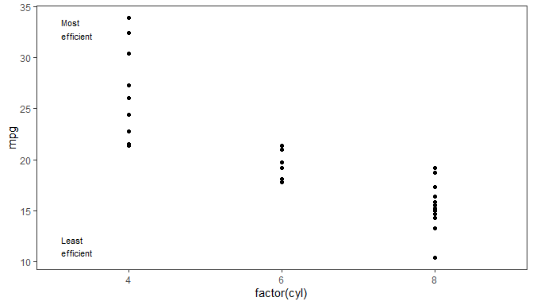

```r
p1 <- ggplot(mtcars, aes(factor(cyl), mpg)) +
  geom_point() +
  geom_text_npc(data = data.frame(x = c("left", "left"),
                                  y = c("top", "bottom"),
                                  label = c("Most\nefficient",
                                            "Least\nefficient")),
                mapping = aes(npcx = x, npcy = y, label = label),
                size = 3)
p1
```

The advantage of this approach becomes apparent when the limits of the *y* scale are unknown or vary. When a script or user defined plotting function sets the scale limits based on the input data, in the absence of the extensions proposed here, setting annotations consistently within the plotting area becomes laborious. The example below, shows how the annotations remain at the desired position when the *y* scale limts are expanded.

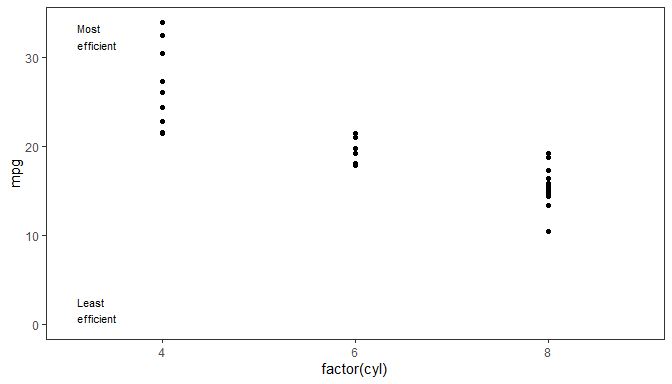

```r
p1 + expand_limits(y = 0)
```

To support the existing syntax for annotations using the new geometries, function `ggplot2::annotate()` is overridden when package ‘ggpmisc’ is loaded. The new definition adds support for the new pseudo-aesthetics *npcx* and *npcy* retaining its original ‘ggplot2’ behaviour in all other respects.

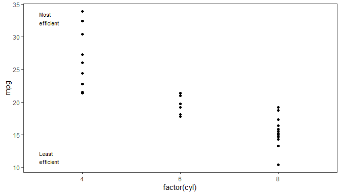

```r
ggplot(mtcars, aes(factor(cyl), mpg)) +
  geom_point() +
  annotate(geom = "text_npc",
           npcx = c("left", "left"),
           npcy = c("top", "bottom"),
           label = c("Most\nefficient",
                     "Least\nefficient"),
           size = 3)
```

Inset plots can be added with the same syntax using `geom_plot_npc()`. They can be thought also as being annotations. Here we use `annotate()` but `geom_plot()` can be also used directly, in which case the inset plots can be different for each panel.

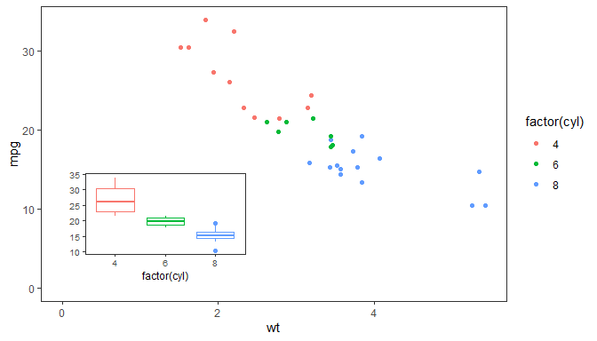

```r
p2 <- ggplot(mtcars, aes(factor(cyl), mpg, colour = factor(cyl))) +
  stat_boxplot() +
  labs(y = NULL) +
  theme_bw(9) +
  theme(legend.position = "none",
        panel.grid = element_blank())

ggplot(mtcars, aes(wt, mpg, colour = factor(cyl))) +
  geom_point() +
  annotate("plot_npc", npcx = "left", npcy = "bottom", label = p2) +
  expand_limits(y = 0, x = 0)
```

A simple example with facets, labeling of panels in a traditional way as requiered by some book and journal styles. In this case panel tags within the plotting are at same “npc” location with free scale limits in panels.

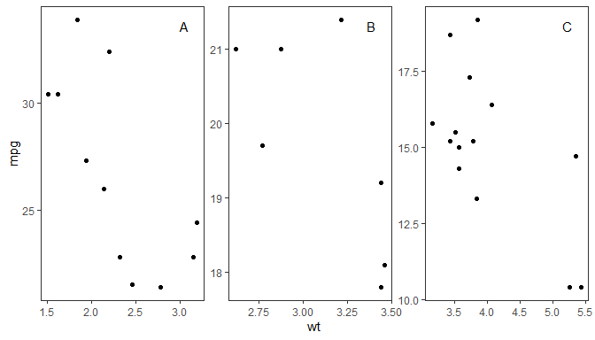

```r
ggplot(mtcars, aes(wt, mpg)) +
  geom_point() +
  geom_text_npc(data = data.frame(cyl = levels(factor(mtcars$cyl)),
                                  label = LETTERS[seq_along(levels(factor(mtcars$cyl)))],
                                  x = 0.90,
                                  y = 0.95),
                mapping = aes(npcx = x, npcy = y, label = label),
                size = 4) +
  facet_wrap(~factor(cyl), scales = "free") +
  theme(strip.background = element_blank(),
        strip.text = element_blank())
```

## When to use annotations and when insets

Package ‘ggpmisc’ adds support for various plot annotations and reference guides. It also adds support for some data labels related to data features. While developing these statistics, it became clear that expanding the grammar of graphics’s support for annotations would simplify the code of these statistics considerably and also more cleanly separate the computations on data from the positioning of annotations.

**Table**. Geometries useful for data labels and annotations. Currently implemented *ordinary* geometries and their *npc* versions. The rightmost column shows the expected class of the objects mapped to the `label` aesthetic. When using `annotate()` to add a single plot, table or grob as an inset, enclosing them in a list is allowed, but not a requirement.

| Data labels (data coordinates) | Annotations (npc) | Mapped to `label` aesthetic |
| --- | --- | --- |
| `ggplot2::geom_text()` | `geom_text_npc()` | `character` vector |
| `ggplot2::geom_label()` | `geom_label_npc()` | `character` vector |
| `ggrepel::geom_text_repel()` |  | `character` vector |
| `ggrepel::geom_label_repel()` |  | `character` vector |
| `ggplot2::geom_label()` | `geom_label_npc()` | `character` vector |
| `geom_linked_text()` | *coming soon* | `character` vector |
| `geom_plot()` | `geom_plot_npc()` | `list()` of `ggplot2::gg` |
| `geom_table()` | `geom_table_npc()` | `list()` of `data.frame` |
| `geom_grob()` | `geom_grob_npc()` | `list()` of `grid::grob` |

When adding an informative element to a plot, assess whether it is an *annotation* or a *data label*. To decide on the best approach, consider if the location of the element is more “naturally” expressed in the original data units or as position relative to the edges or centre of the plotting area. In the second case, prefer the “npc” geoms as you are dealing with *annotations*, otherwise, use the ordinary geometries as you are dealing with data labels or data points.

## Positioning data labels

Nudging is normally used to displace text labels so that they do not overlap the points or lines representing the data being labeled. Two enhanced versions of `position_nudge()` are provided, `position_nudge_center()` and `position_nudge_line()`. These functions make it possible to apply nudging that varies automatically according to the relative position of points with respect to arbitrary points or lines, or with respect to a polynomial or smoothing spline fitted on-the-fly to the the observations.

## Highlighting data features

If maxima or minima are to be labeled in a plot, this can be automated so that the feature and its labelling is automated. This is possible with `stat_peaks()` and `stat_valleys()`. Marginal annotations with symbols and vertical and horizontal lines can be used to highlight summary values or events/conditions. The *geoms* `geom_quadrant_lines()`, `geom_vhlines()`, `geom_x_margin_arrow()`, `geom_x_margin_grob()`, `geom_x_margin_point()`, `geom_y_margin_arrow()`, `geom_y_margin_grob()` and `geom_y_margin_point()` make such labelling easy.

## Local density of observations

There are to aspects to this: highlighting with colours dense or sparse regions, or using density to decide which observations to label. In this cases we can use `stat_dens1d_labels()` and `stat_dens2d_labels()`, `stat_dens1d_filter()` and `stat_dens2d_filter()`, and `stat_dens1d_filter_g()` and `stat_dens2d_filter_g()`.

## Summary statistics

With some types of data it is common to compute summary per quadrant, rather than based on a prior grouping. The *stat* `stat_quadrant_counts()` can de used to annotate plots with the number of observations in each quadrant. `stat_summary_xy()` is similar to `stat_summary()` from ‘ggplot2’ but useful when both *x* and *y* are continuous variables. It allows the use the same, or different functions to summarise the data over *x* and *y*. In contrast `stat_centroid()` always applies the same function over *x* and *y*.

## ggplot methods

Being `ggplot()` defined as a generic method in ‘ggplot2’ makes it possible to define specializations, and we provide two for time series stored in objects of classes `ts` and `xts` which automatically convert these objects into tibbles and set by default the aesthetic mappings for `x` and `y` automatically. A companion function `try_tibble()` is also exported.

## Thoughts for the future

Although we have discussed only scales for *x* and *y* aesthetics, the same consideration applies to other aesthetics like *colour*. It seems generally useful to allow aesthetics to use a different scale for annotations than for data. Defining pseudo-aesthetics for annotations instead of allowing multiple scales for each aesthetic in a plot would add flexibility while still keeping the guarantee that the meaning of aesthetics values remains consistent across all plot elements representing data.

## List of references

Koponen, J; Hildén, J. (2019) *Data visualization handbook*. Aalto ARTS books, Espoo. ISBN 978-952-60-7449-8.

Wickham H. (2010) A Layered Grammar of Graphics. *Journal of Computational and Graphical Statistics* **19:** 3–28.

Wickham H. (2016) *ggplot2*. Springer International Publishing. ISBN 978-3-319-24275-0.

# Examples

## ggplot methods

`ggplot()` methods for classes `"ts"` and `"xts"` automate plotting of time series data, as *x* and *y* aesthetics are mapped to time and the variable of the time series, respectively. For plotting time series data stored in objects of other classes, see the conversion functions `try_tibble()` and `try_data_frame()` in the last section of this vignette.

By default, `time` is of class `Date` or of class `POSIXct` depending on how time is stored in the time series object. On-the-fly coversion of `time` to `numeric` is possible (shown in the second example below).

```r
class(lynx)
```

```
## [1] "ts"
```

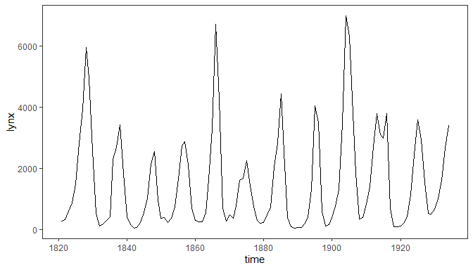

```r
ggplot(lynx) + geom_line()
```

Whether the class variable `time`affects the scale used by default as well as the formatting of values when converted to character strings or printed.

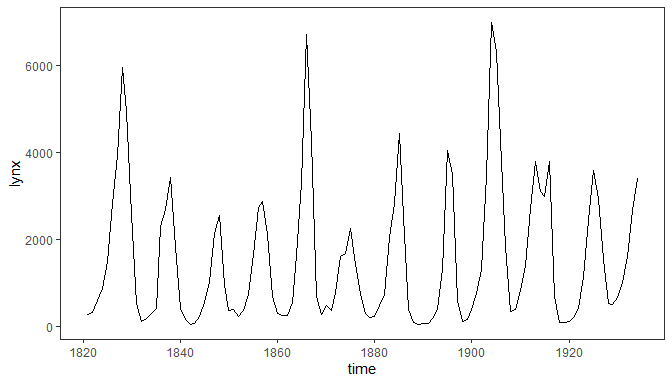

```r
ggplot(lynx, as.numeric = FALSE) + geom_line()
```

## Geometries

Three of the geometries described below allow the addition of plot layers containing insets. Insets can be plots, tables, bitmaps, or grid objects. Insets can be also added as annotations. Using for `data` a tibble with a list column containing data frames or tibbles allows like any other geom, the use of grouping, multiple insets per panel, faceting with different tables per panel, and different number of insets in each panel, i.e., individual tables added to a plot with `geom_table` behave similarly to individual `character` values added with `geom_text`.

Other geometries also described in this section support the use of native plot coordinates for positioning elements in the plotting area. Obviously these geometries are not meant to be used to display data, but instead they make it possible to add annotations to plots consistently across data sets and varying scales used.

### geom_table() and stat_fmt_table()

The *geometry* `geom_table()` plots a data frame or tibble, nested in a tibble passed as data argument, using *aesthetics* `x` and `y` for positioning, and `label` for the list of data frames containing the data for the tables. The tables are created as a ‘grid’ grobs and added as usual to the ggplot object. In contrast to “standard” geoms, this geom by default does not inherit the globally mapped aesthetics.

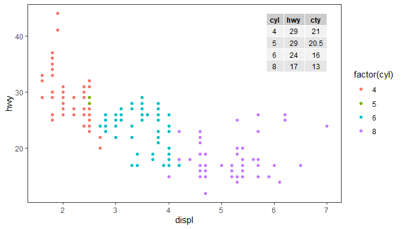

```r
tb <- mpg %>%
  group_by(cyl) %>%
  summarise(hwy = median(hwy), cty = median(cty))

data.tb <- tibble(x = 7, y = 44, tb = list(tb))

ggplot(mpg, aes(displ, hwy, colour = factor(cyl))) +
  geom_table(data = data.tb, aes(x, y, label = tb)) +
  geom_point()
```

In plots with a single panel it is easier to use `annotate()` to add inset tables, giving the same plot as above. In this case single data frames, ggplots or grobs do not need to be wrapped in a list, although lists are also supported.

```r
tb <- mpg %>%
  group_by(cyl) %>%
  summarise(hwy = median(hwy), cty = median(cty))

ggplot(mpg, aes(displ, hwy, colour = factor(cyl))) +
  annotate("table", x = 7, y = 44, label = tb) +
  geom_point()
```

Table themes are supported through parameter `table.theme` and if variables or constants are mapped to the `colour`, `fill`, `size`, `family`, aesthetics they override the corresponding theme settings. The display of `rownames` and `colnames` can be enabled or disable through parameter `table.rownames` and `table.colnames` and the horizontal justification of text in the core of the table through parameter `table.hjust`.

Parameter `table.theme` accepts as arguments `NULL` for use of the current default, a `ttheme` constructor function such as those defined in package ‘gridExtra’, or the variations on them defined in this package. The current default can be set with function `ttheme_set()`.

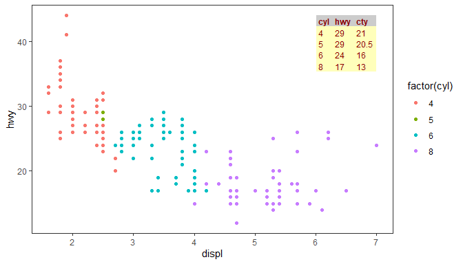

```r
ggplot(mpg, aes(displ, hwy, colour = factor(cyl))) +
  geom_table(data = data.tb, aes(x, y, label = tb),
             table.theme = ttheme_gtsimple,
             table.hjust = 0, colour = "darkred", fill = "#FFFFBB") +
  geom_point()
```

Using `stat_fmt_tb()` we can rename columns and rows of the tibble, reorder them and/or select a subset of columns or rows as shown below. To provide a complete example we also replace the names of the scales for *x*, *y* and *color* aesthetics. Here we pass a `character` vector with the original names of the columns in full, but partial matching is tried when needed. It is also possible to use a `numeric` vector of positional indexes.

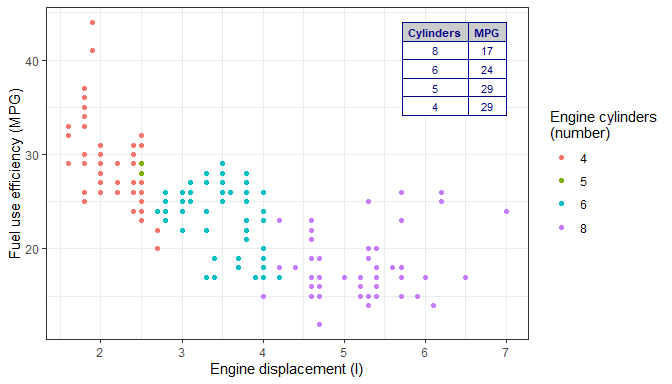

```r
ggplot(mpg, aes(displ, hwy, colour = factor(cyl))) +
  geom_table(data = data.tb, aes(x, y, label = tb),
             table.theme = ttheme_gtlight,
             size = 3, colour = "darkblue",
             stat = "fmt_tb",
             tb.vars = c(Cylinders = "cyl", MPG = "hwy"), # rename
             tb.rows = 4:1) + # change order
  labs(x = "Engine displacement (l)", y = "Fuel use efficiency (MPG)",
       colour = "Engine cylinders\n(number)") +
  geom_point() +
  theme_bw()
```

Parsed text, using plot math syntax is supported in the table, with fall-back to plain text in case of parsing errors, on a cell by cell basis. Here we plot the MPG for city traffic and we can see that the plotting area expands to include the coordinates at which the table is anchored. Justification is by default set to `"inward"` which ensures that the table is fully within the plotting region.

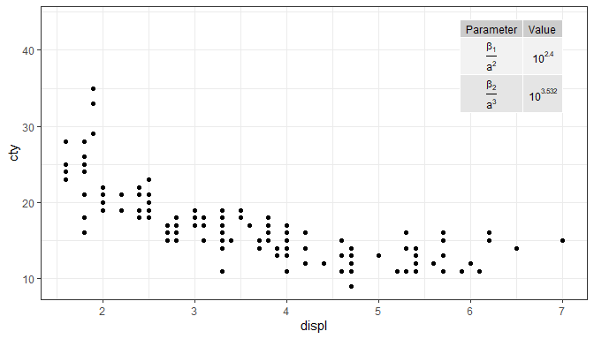

```r
tb.pm <- tibble(Parameter = c("frac(beta[1], a^2)", "frac(beta[2], a^3)"),
                Value = c("10^2.4", "10^3.532"))
data.tb <- tibble(x = 7, y = 44, tb = list(tb.pm))
ggplot(mpg, aes(displ, cty)) +
  geom_point() +
  geom_table(data = data.tb, aes(x, y, label = tb), parse = TRUE) +
  theme_bw()
```

As implemented, there is no limitation to the number of insets, and faceting is respected. If the base plot shows a map, multiple small tables could be superimposed on different countries or regions. The size of the insets is set relative to the main plot, so the combined plot can be scaled.

Please see section **Normalised Parent Coordinates** below for a description of `geom_table_npc()`.

### geom_plot()

The `geom_plot()` *geometry* plots ggplot objects, nested in a tibble passed as data argument, using *aesthetics* `x` and `y` for positioning, and `label` for the ggplot object containing the definition of the plot to be nested. With this approach in plots with facets the insets can be different in each panel. It is also possible to inset more than one plot in a single call simply by creating a tibble with multiple rows.

Behind the scenes, one Grob is created for each plot to be inset. The conversion is done with `ggplotGrob()` and the Grobs added the main ggplot object.

As an example we produce a plot where the inset plot is a zoomed-in detail from the main plot. In this case the main and inset plots start as the same plot. In most cases the size of text and other elements in the inset should be smaller than in the main plot. Here we override the default theme setting the `base_size` from its default of 11 pt to 8 pt.

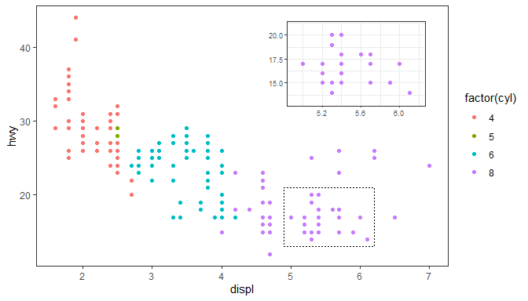

```r
p <- ggplot(mpg, aes(displ, hwy, colour = factor(cyl))) +
  geom_point()

data.tb <-
  tibble(x = 7, y = 44,
         plot = list(p +
                       coord_cartesian(xlim = c(4.9, 6.2),
                                       ylim = c(13, 21)) +
                       labs(x = NULL, y = NULL) +
                       theme_bw(8) +
                       scale_colour_discrete(guide = FALSE)))

ggplot(mpg, aes(displ, hwy, colour = factor(cyl))) +
  geom_plot(data = data.tb, aes(x, y, label = plot)) +
  annotate(geom = "rect",
           xmin = 4.9, xmax = 6.2, ymin = 13, ymax = 21,
           linetype = "dotted", fill = NA, colour = "black") +
  geom_point()
```

In general, the inset plot can be any ggplot object, allowing the creation of very different combinations of main plot and inset plots. Here we use the inset to show summaries as in the previous example of an inset table.

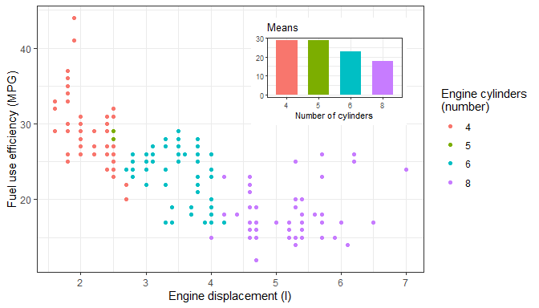

```r
p <- ggplot(mpg, aes(factor(cyl), hwy, fill = factor(cyl))) +
  stat_summary(geom = "col", fun = mean, width = 2/3) +
  labs(x = "Number of cylinders", y = NULL, title = "Means") +
  scale_fill_discrete(guide = FALSE)

data.tb <- tibble(x = 7, y = 44,
                  plot = list(p +
                                theme_bw(8)))

ggplot(mpg, aes(displ, hwy, colour = factor(cyl))) +
  geom_plot(data = data.tb, aes(x, y, label = plot)) +
  geom_point() +
  labs(x = "Engine displacement (l)", y = "Fuel use efficiency (MPG)",
       colour = "Engine cylinders\n(number)") +
  theme_bw()
```

The same plot as above can be created using `annotate()` but be aware that when using facets in ‘ggplot2’ annotations are identical in all panels.

```r
p <- ggplot(mpg, aes(factor(cyl), hwy, fill = factor(cyl))) +
  stat_summary(geom = "col", fun = mean, width = 2/3) +
  labs(x = "Number of cylinders", y = NULL, title = "Means") +
  scale_fill_discrete(guide = FALSE)

ggplot(mpg, aes(displ, hwy, colour = factor(cyl))) +
  annotate("plot", x = 7, y = 44, label = p + theme_bw(8)) +
  geom_point() +
  labs(x = "Engine displacement (l)", y = "Fuel use efficiency (MPG)",
       colour = "Engine cylinders\n(number)") +
  theme_bw()
```

As implemented, there is no limitation to the number of insets, and faceting is respected. If the base plot shows a map or a bitmap, multiple small plots could be superimposed on different countries or regions. The size of the insets is set relative to the main plot, so the combined plot can be scaled. A possible unintuitive but useful feature, is that the theme is linked to each plot.

Please see section **Normalised Parent Coordinates** below for a description of `geom_plot_npc()`.

### geom_grob()

The `geom_grob()` *geometry* plots grobs (graphical objects as created with ‘grid’), nested in a tibble passed as data argument, using *aesthetics* `x` and `y` for positioning, and `label` for the Grob object. While `geom_table()` and `geom_plot()` take as values to plot tibbles or data frames, and ggplots, respectively, and convert them into Grobs before adding them to the plot, `geom_grob()` expects Grobs ready to be rendered.

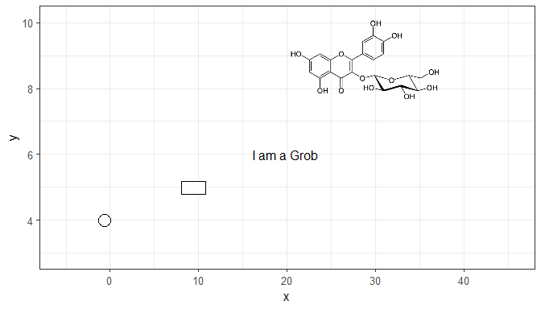

```r
file.name <-
  system.file("extdata", "Isoquercitin.png",
              package = "ggpmisc", mustWork = TRUE)
Isoquercitin <- magick::image_read(file.name)
grobs.tb <- tibble(x = c(0, 10, 20, 40), y = c(4, 5, 6, 9),
                   width = c(0.05, 0.05, 0.01, 1),
                   height =  c(0.05, 0.05, 0.01, 0.3),
                   grob = list(grid::circleGrob(),
                               grid::rectGrob(),
                               grid::textGrob("I am a Grob"),
                               grid::rasterGrob(image = Isoquercitin)))

ggplot() +
  geom_grob(data = grobs.tb,
            aes(x, y, label = grob, vp.width = width, vp.height = height),
            hjust = 0.7, vjust = 0.55) +
  scale_y_continuous(expand = expansion(mult = 0.3, add = 0)) +
  scale_x_continuous(expand = expansion(mult = 0.2, add = 0)) +
 theme_bw(12)
```

As shown above for inset tables and inset plots, it is also possible to use `annotate()` with Grobs. The next example insets a single `Grob`. Here we reuse the bitmap `Isoquercitin` read in the previous example. The Grob is contained in a viewport. Here setting `width = 1` (“npc” units) when creating the `Grob` from the bitmap ensures that the bitmap fills the width of the viewport (to ensure that the inset is not distorted, set only one of `width` or `height`). The argument to `vp.width` or `vp.height`, also in “npc” units, determines the size of the `Grob` relative to the size of the plotting area.

```r
ggplot() +
  annotate("grob", x = 1, y = 3, vp.width = 0.5,
           label = grid::rasterGrob(image = Isoquercitin, width = 1)) +
 theme_bw(12)
```

`geom_grob()` is designed thinking that its main use will in graphical annotations, although one could use it for infographics with multiple copies of each grob, this would go against the grammar of graphics. In this implementation grobs cannot be mapped to an aesthetic through a scale.

As implemented, there is no limitation to the number of insets and faceting is respected. If the base plot shows a map or a bitmap, multiple simple grobs (e.g. national flags) could be superimposed on different countries. The size of the insets is set relative to the main plot, so the combined plot can be scaled.

Please see section **Normalised Parent Coordinates** below for a description of `geom_grob_npc()`.

### geom_vhlines()

This is a convenience geometry that adds both vertical and horizontal guide lines on the same plot layer, using the same syntax as `geom_hline()` and `geom_vline()` from package ‘ggplot2’.

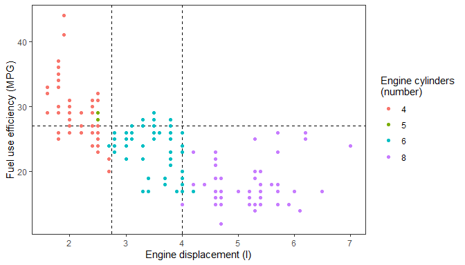

```r
ggplot(mpg, aes(displ, hwy, colour = factor(cyl))) +
  geom_vhlines(xintercept = c(2.75, 4), yintercept = 27, linetype = "dashed") +
  geom_point() +
  labs(x = "Engine displacement (l)", y = "Fuel use efficiency (MPG)",
       colour = "Engine cylinders\n(number)")
```

### geom_linked_text()

With package ‘ggrepel’ we have become used to easily add text and labels linked to the labeled observations or points by a line segment or arrow. However, sometimes a plot has few text labels and repulsion is unnecessary. In such cases nudging or dodging may be enough, or even preferable so as to achieve consistency.

We can achieve this with `geom_linked_text()` together with a suitable position function that retains the original *x* and *y* coordinates of the point. We currently provide two different, and flexible nudge functions described in a later section. One of them is used by default providing the same default behaviour as `geom_text()` from ‘ggplot2’ but drawing linking segments if nudging is set to a value different to the default of zero.

**Please, be aware that this is a preliminary implementation, whose user interface and behavior are very likely to change in coming months.**

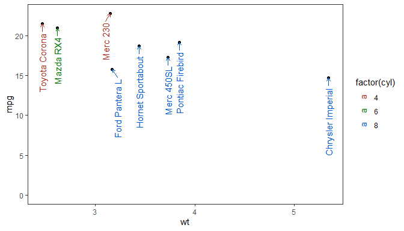

```r
my.cars <- mtcars[c(TRUE, FALSE, FALSE, FALSE), ]
my.cars$name <- rownames(my.cars)
my.cars <- my.cars[order(my.cars$wt), ]
ggplot(my.cars, aes(wt, mpg, label = name)) +
  geom_point() +
  geom_linked_text(aes(colour = factor(cyl)),
                   angle = 90,
                   hjust = 1.04, nudge_y = -1,
                   nudge_x = c(0, 0, -0.05, +0.05, 0, 0 ,0, 0),
                   arrow = arrow(length = grid::unit(1.5, "mm"))) +
  scale_colour_discrete(l = 40) +
  expand_limits(y = 0)
```

### Normalised Parent Coordinates

R’s ‘grid’ package defines several units that can be used to describe the locations of plot elements. In ‘ggplot2’ the *x* and *y* aesthetics are directly mapped to `"native"` or data units. For consistent location of **annotations** with respect to the plotting area we need to rely on `"npc"` which are expressed relative to the size of the grid viewport. The plotting area in a ggplot is implemented as viewport and support for `"npc"` coordinates is relatively easy to implement.

To support `"npc"` positions we have implemented *scales* for two new *aesthetics*, `npcx` and `npcy`. These are very simple continuous scales which do not support any transformation or changes to their limits, both of which would be meaningless for `"npc"` units. Variables mapped to these aesthetics can be either numerical with values in the range zero to one or character. A limited set of strings are recognised and converted to `"npc"` units: `"bottom"`, `"center"`, `"top"`, `"left"`, `"middle"`, `"right"` (`"centre"` is a synonym for `"center"`).

To make these scales useful we need also to define *geometries* that use these new aesthetics. Package ‘ggpmisc’ currently provides `geom_text_npc()`, `geom_label_npc()`, `geom_table_npc()`, `geom_plot_npc()` and `geom_grob_npc()`.

As is the case for `geom_text()` and `geom_label()` from package ‘ggplot2’, `"bottom"`, `"center"`, `"top"`, `"left"`, `"middle"`, `"right"`, plus `"inward"` and `"outward"` can be used, as well as numeric values, to control the justification. Justification defaults to `"inward"` in the geometries described here.

While the usual *x* and *y* aesthetics are used whenever the positions of plot elements represent data values, these new scales and geometries are useful only for annotations, i.e., in those cases when we want plot elements at specific positions within the plotting area irrespective of the ranges of the data mapped to the *x* and *y* aesthetics. When writing scripts or functions that may be applied to different data sets these new *aesthetics* help by keeping the code concise and reusable. These *geometries* are used by default by several of the statistics described in later sections.

As an example let’s imagine that we want to add the structure of a metabolite to a plot. Its position has nothing to do with the data mapped to *x* and *y*, so it is conceptually better to use `"npc"` coordinates. The big practical advantage is that this also allows to keep this part of the plot definition independent of the data being plotted, giving a major advantage in the case of plots with facets with free scale limits. This example can be easily adapted to `geom_plot_npc()` where a ggplot should mapped to `label`, and to `geom_table_npc()` where a data frame should be mapped to `label`.

We produce the example plot by first constructing a tibble to contain the grob and the coordinate data, and then map these variables to aesthetics using `aes()`. In the example the tibble has a single row, but this is not a requirement. In this respect these geoms behave as normal geoms, with facets also supported.

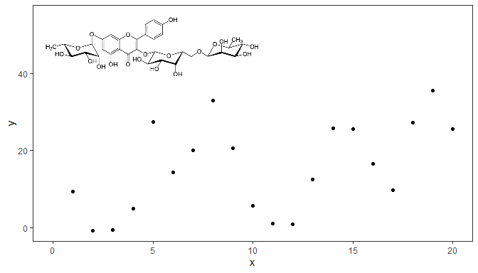

```r
file.name <-
  system.file("extdata", "Robinin.png",
              package = "ggpmisc", mustWork = TRUE)
Robinin <- magick::image_read(file.name)

set.seed(123456)
data.tb <- tibble(x = 1:20, y = (1:20) + rnorm(20, 0, 10))

flavo.tb <- tibble(x = 0.02,
                   y = 0.95,
                   width = 1/2,
                   height = 1/4,
                   grob = list(grid::rasterGrob(image = Robinin)))

ggplot(data.tb, aes(x, y)) +
  geom_grob_npc(data = flavo.tb,
                aes(label = grob, npcx = x, npcy = y,
                    vp.width = width, vp.height = height)) +
  geom_point() +
  expand_limits(y = 55, x = 0)
```

Alternatively, we can pass constant values to `geom_grob_npc()` to obtain the same plot. This approach can be handy in simple cases.

```r
ggplot(data.tb, aes(x, y)) +
  geom_grob_npc(label = list(grid::rasterGrob(image = Robinin, width = 1)),
                npcx = 0.02, npcy = 0.95,
                vp.width = 1/2, vp.height = 1/4) +
  geom_point() +
  expand_limits(y = 55, x = 0)
```

We can also use `annotate()` if the annotation should be the same for all panels, or if we have a single figure panel. In this case there is no need to wrap a single `grob` in a list.

```r
ggplot(data.tb, aes(x, y)) +
  annotate("grob_npc", label = grid::rasterGrob(image = Robinin, width = 1),
                npcx = 0.02, npcy = 0.95, vp.width = 1/2, vp.height = 1/4) +
  geom_point() +
  expand_limits(y = 55, x = 0)
```

Two additional geometries are based on existing ‘ggplot2’ geometries. They are based on `geom_text()` and `geom_label()`. We give an example using `geom_text_npc()` to produce a “classic” labelling for facets matching the style of `theme_classic()` and traditional scientific journals’ design.

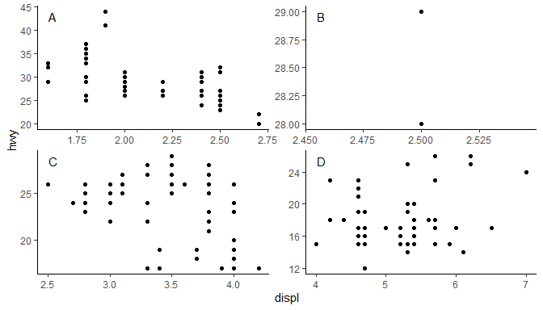

```r
corner_letters.tb <- tibble(label = LETTERS[1:4],
                            x = "left",
                            y = "top",
                            cyl = c(4,5,6,8))
ggplot(mpg, aes(displ, hwy)) +
  geom_point() +
  facet_wrap(~cyl, scales = "free") +
  geom_text_npc(data = corner_letters.tb,
                aes(npcx = x, npcy = y, label = label)) +
  theme_classic() +
  theme(strip.background = element_blank(),
        strip.text.x = element_blank())
```

### Marginal markings

‘ggplot2’ provides `geom_rug()`, `geom_vline()` and `geom_hline()`. Rug plots are intended to be used to represent distributions along the margins of plot. `geom_vline()` and `geom_hline()`are normally used to separate regions in a plot or to highlight important values along the *x* or *y* axis. When creating plots it is sometimes useful to put small marks along the axes, just inside the plotting area, similar to those in a rug plot, but like `geom_vline()` and `geom_hline()` in their purpose.

Three *geometries* provide such markers: `geom_margin_point()`, `geom_margin_arrow()`, and `geom_margin_grob()`. They behave similarly to `geom_vline()` and `geom_hline()` and their positions are determined also by the `xintercept` and `yintercept` aesthetics.

In the example below we indicate the group medians along the *x* axis with filled triangles.

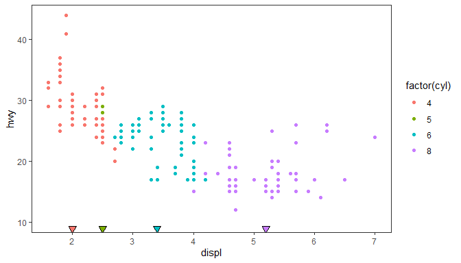

```r
data.tb <- mpg %>%
  group_by(cyl) %>%
  summarise(hwy = median(hwy), displ = median(displ))
ggplot(mpg, aes(displ, hwy, colour = factor(cyl))) +
  geom_x_margin_point(data = data.tb,
                      aes(xintercept = displ, fill = factor(cyl))) +
  expand_limits(y = 10) +
  geom_point()
```

## Statistics

### stat_centroid()

It can be useful to mark the centroid of a group of observations with a point or with a label. By default `stat_centroid()` applies function `mean()` to both `x` and `y` by group. If all the values mapped to `label` within each group are identical, this value is copied to the returned `data`.

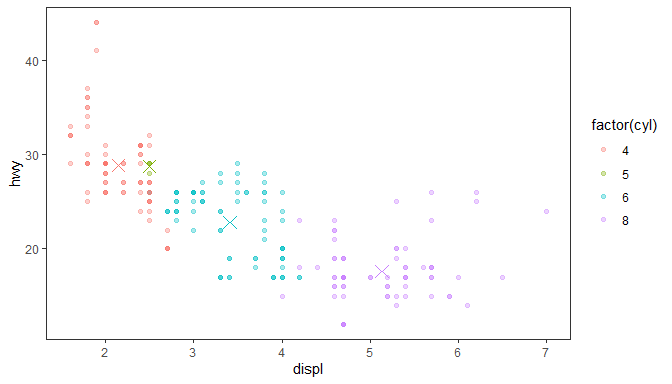

```r
ggplot(mpg, aes(displ, hwy, colour = factor(cyl))) +
  geom_point(alpha = 0.33) +
  stat_centroid(shape = "cross", size = 4)
```

Other functions can be passed to this statistic as long as they return a single value that can be mapped to the `x` and `y` aesthetics (numeric, time or a factor).

```r
ggplot(mpg, aes(displ, hwy, colour = factor(cyl))) +
  geom_point(alpha = 0.33) +
  stat_centroid(shape = "cross", size = 4, .fun = median)
```

The very similar `stat_summary_xy()` accepts different functions for `x` and `y`.

### stat_quadrant_counts() and geom_quadrant_lines()

This statistic automates the annotation of plots with number of observations, either by quadrant, by pairs of quadrants or the four quadrants taken together (whole plotting area). Its companion geometry, `geom_quadrant_lines()` is used in the examples to highlight the quadrants.

We generate some artificial data.

```r
set.seed(4321)
# generate artificial data
x <- -99:100
y <- x + rnorm(length(x), mean = 0, sd = abs(x))
my.data <- data.frame(x,
                      y,
                      group = c("A", "B"))
```

Using defaults except for color.

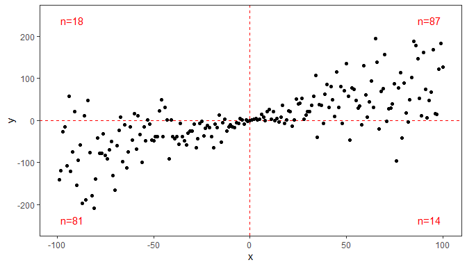

```r
ggplot(my.data, aes(x, y)) +
  geom_quadrant_lines(colour = "red") +
  stat_quadrant_counts(colour = "red") +
  geom_point() +
  expand_limits(y = c(-250, 250))
```

Pooling quadrants along the *x*-axis. (`pool.along = "y"` pools along *y*.)

```r
ggplot(my.data, aes(x, y)) +
  geom_quadrant_lines(colour = "red", pool.along = "x") +
  stat_quadrant_counts(colour = "red", pool.along = "x") +
  geom_point()
```

Manual positioning of the text annotations and pooling of all four quadrants, and overriding the default formatting for the label.

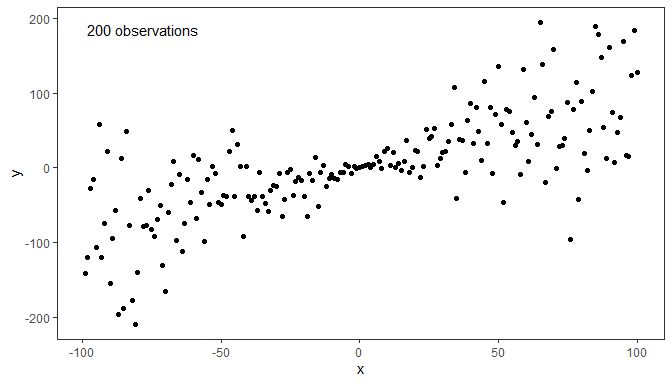

```r
ggplot(my.data, aes(x, y)) +
  geom_point() +
  stat_quadrant_counts(quadrants = 0L, label.x = "left",
                       aes(label = sprintf("%i observations", stat(count))))
```

Annotation of only specific quadrants.

```r
ggplot(my.data, aes(x, y)) +
  geom_quadrant_lines(colour = "red") +
  stat_quadrant_counts(colour = "red", quadrants = c(2, 4)) +
  geom_point()
```

Using facets, even with free scale limits, the labels are placed consistently. This achieved by the default use of `geom_text_npc()` or as shown below by use of `geom_label_npc(). We expand the *y* limits to ensure that no observations are occluded by the labels.

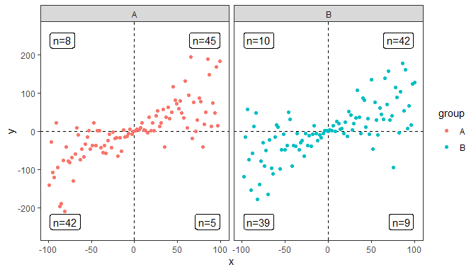

```r
ggplot(my.data, aes(x, y, colour = group)) +
  geom_quadrant_lines() +
  stat_quadrant_counts(geom = "label_npc") +
  geom_point() +
  expand_limits(y = c(-260, 260)) +
  facet_wrap(~group)
```

### stat_apply_group and stat_apply_panel

These statistics apply a function to `x` and `y` data. The function is expected to return a vector of the same length as its input. It is usually better to apply such functions through mappings using `aes()` when they are independent of grouping or to use a transformation for the scale. However, when grouping is important, these statistics solve a problem that would otherwise require pre-computation of the data. Here we plot the difference in circumference between dates for each tree. (As the vector returned by `diff()` is one element shorter than its input, we prepend `NA`.) However, scale limits are not recomputed and modifying them would exclude observations. Consequently, in this case we need to manualy set the limit in `coord_cartesian()`.

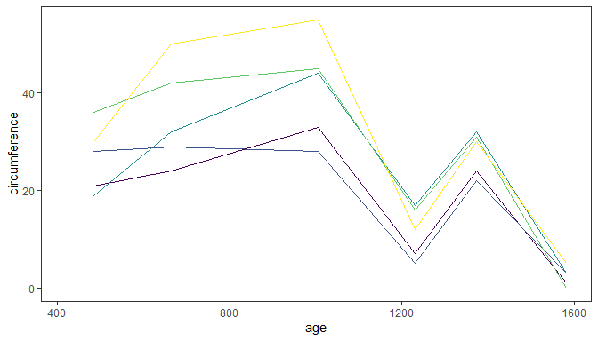

```r
ggplot(Orange, aes(age, circumference, colour = Tree)) +
  stat_apply_group(.fun.y = function(x) {c(NA, diff(x))}, na.rm = TRUE) +
  coord_cartesian(xlim = c(420, NA))
```

### stat_peaks() and stat_valleys()

Two statistics make it possible to highlight and/or label peaks and valleys (local maxima and local minima) in a curve. Here we use a time series, using `Date` objects for `time` and the default formatting of labels. We also instruct `geom_text()` not to render overlapping labels. They support numeric, date or datetime mapped to the *x* aesthetic. Currently a numeric variables has to be mapped to the *y* aesthetic.

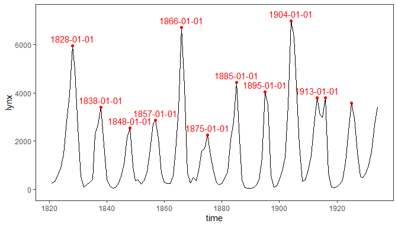

```r
ggplot(lynx, as.numeric = FALSE) + geom_line() +
  stat_peaks(colour = "red") +
  stat_peaks(geom = "text", colour = "red", vjust = -0.5,
             check_overlap = TRUE) +
  ylim(-100, 7300)
```

A plot using `numeric` values for `time` and the default formatting of labels. We can also pass other aesthetics recognised the `geom_text()` such as `angle`. Here we also highlight and label the valleys.

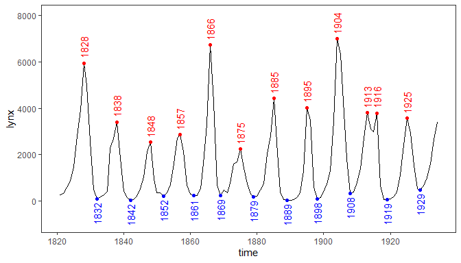

```r
ggplot(lynx) + geom_line() +
  stat_peaks(colour = "red") +
  stat_peaks(geom = "text", colour = "red", hjust = -0.2, vjust = 0.5,
             angle = 90, check_overlap = TRUE) +
  stat_valleys(colour = "blue") +
  stat_valleys(geom = "text", colour = "blue", hjust = 1.2, vjust = 0.5,
             angle = 90, check_overlap = TRUE) +
  expand_limits(y = c(-900, 8000))
```

We can obtain a very similar plot using `Date` for `time` but supplying a format string. In addition marking both peaks and valleys.

```r
ggplot(lynx, as.numeric = FALSE) + geom_line() +
  stat_peaks(colour = "red") +
  stat_peaks(geom = "text", colour = "red", hjust = -0.2, vjust = 0.5,
             angle = 90, check_overlap = TRUE, x.label.fmt = "%Y") +
  stat_valleys(colour = "blue") +
  stat_valleys(geom = "text", colour = "blue", hjust = 1.2, vjust = 0.5,
             angle = 90, check_overlap = TRUE, x.label.fmt = "%Y") +
  expand_limits(y = c(-900, 8000))
```

Using `geom_rug` for the peaks and valleys.

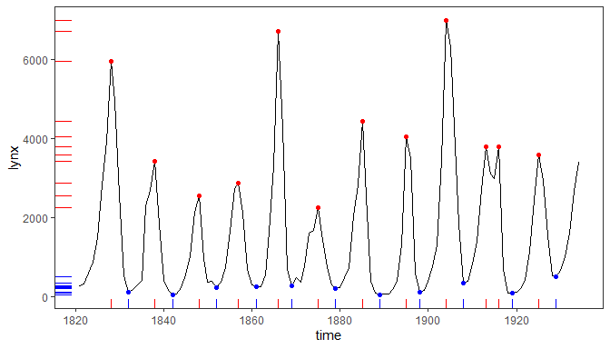

```r
ggplot(lynx, as.numeric = FALSE) + geom_line() +
  stat_peaks(colour = "red") +
  stat_peaks(geom = "rug", colour = "red") +
  stat_valleys(colour = "blue") +
  stat_valleys(geom = "rug", colour = "blue")
```

### stat_dens2d_labels() and stat_dens2d_filter()

These stats had their origin in an enhancement suggestion for ‘ggrepel’ from Hadley Wickham and discussion with Kamil Slowikowski (ggrepel’s author) and others. In fact the code is based on code Kamil gave during the discussion, but simplified and taking a few further ideas from `ggplot::stat_dens2d`.

**Warning!** Which observations are selected by the algorithm used, based on `MASS:kde2d`, depends strongly on the values of parameters `h` and `n`. You may need to alter the defaults by passing explicit arguments to these stats. Beware, though, that what are good values, may depend on individual data sets even if they include the same number of observations. For the selection of observations to work cleanly, the argument for `n` must create a dense grid. Much larger values of `n` than in the examples in the documentation of `MASS::kde2d` and `ggplot2::stat_dens2d` will be needed in most cases.

Some random data with random labels.

```r
random_string <- function(len = 3) {
paste(sample(letters, len, replace = TRUE), collapse = "")
}

# Make random data.
set.seed(1001)
d <- tibble::tibble(
  x = rnorm(100),
  y = rnorm(100),
  group = rep(c("A", "B"), c(50, 50)),
  lab = replicate(100, { random_string() })
)
```

The stat `stat_dens2d_filter` *filters* observations, in other words passes to the geom a subset of the data received as input. The default argument for `geom` is `"point"`.

Using defaults except for the color aesthetic. Highlight 1/4 of observations from lowest density areas of the plot panel.

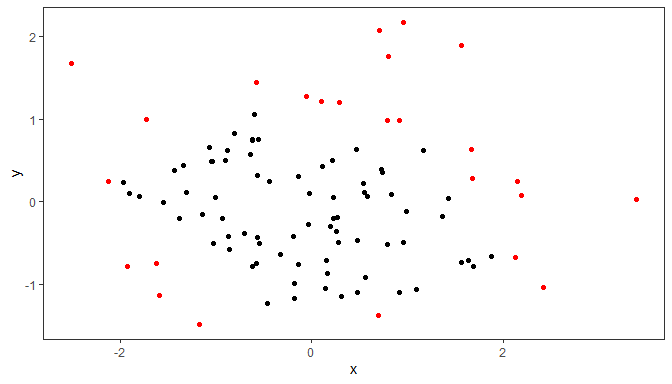

```r
ggplot(data = d, aes(x, y)) +
  geom_point() +
  stat_dens2d_filter(keep.fraction = 1/4, colour = "red")
```

Keep at most 50 observations.

```r
ggplot(data = d, aes(x, y)) +
  geom_point() +
  stat_dens2d_filter(keep.fraction = 1/4, keep.number = 50, colour = "red")
```

Keep always 50 observations.

```r
ggplot(data = d, aes(x, y)) +
  geom_point() +
  stat_dens2d_filter(keep.fraction = 1, keep.number = 50, colour = "red")
```

Highlighting 1/4 of the observations by under-plotting with larger black points.

```r
ggplot(data = d, aes(x, y, colour = group)) +
   stat_dens2d_filter(keep.fraction = 0.25,
                      size = 3,
                      colour = "black") +
   geom_point()
```

A different way of highlighting 1/4 of the observations, using over-plotting with a ‘hollow’ shape. We also shift one group with respect to the other.

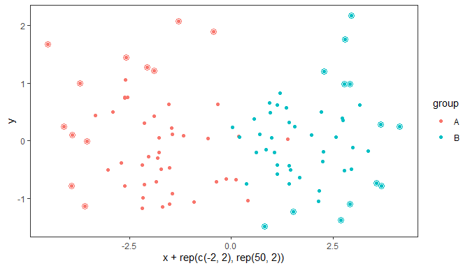

```r
ggplot(data = d, aes(x + rep(c(-2,2), rep(50,2)),
                     y, colour = group)) +
   geom_point() +
   stat_dens2d_filter(shape = 1, size = 3,
                      keep.fraction = 0.25)
```

Highlight 1/4 of observations from lowest density areas of the plot, with density considered separately for each individual group. In this case grouping is based on the color aesthetic.

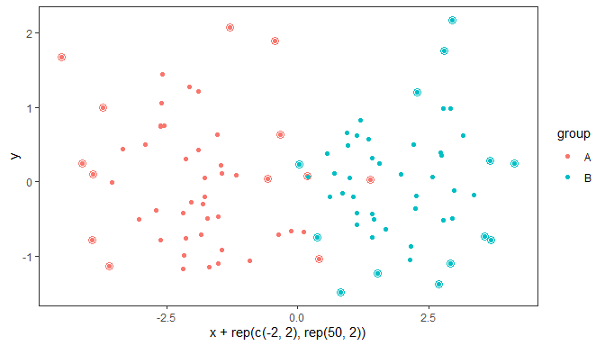

```r
ggplot(data = d, aes(x + rep(c(-2,2), rep(50,2)),
                     y, colour = group)) +
   geom_point() +
   stat_dens2d_filter_g(shape = 1, size = 3,
                      keep.fraction = 0.25)
```

The default value for `geom` is `"text"`. The default value of `label.fill` is `""` which results in empty labels, while using `NA` as fill label results in observations being omitted. Using `NA` as `label.fill` is similar to using `stat_dens2d_filter` as long as the geom used requires a `label` aesthetic.

Label 1/10 of observations from lowest density areas of the plot panels.

```r
ggplot(data = d, aes(x, y, label = lab, colour = group)) +
  stat_dens2d_labels(keep.fraction = 1/10,
                     hjust = "outward", vjust = "outward") +
  geom_point()
```

Using the geoms from package ‘ggrepel’ avoids clashes among labels or on top of data points. This works with versions 0.6.0 and newer of ‘ggrepel’. One example with `geom_text_repel` follows.

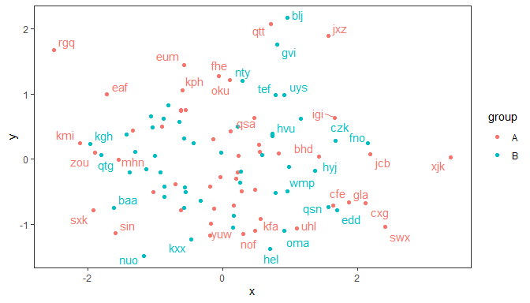

```r
ggplot(data = d, aes(x, y, label = lab, colour = group)) +
  geom_point() +
  stat_dens2d_labels(geom = "text_repel",
                     keep.fraction = 0.45)
```

With `geom_label_repel` one usually needs to use a smaller value for `keep.fracton`, or a smaller `size`, as labels use more space on the plot than the test alone.

Additional arguments can be used to change the angle and position of the text, but may give unexpected output when labels are long as the repulsion algorithm “sees” always a rectangular bounding box that is not rotated. With short labels or angles that are multiples of 90 degrees, there is no such problem. Please, see the documentation for `ggrepel::geom_text_repel` and `ggrepel::geom_label_repel` for the various ways in which both repulsion and formatting of the labels can be adjusted.

Using `NA` as argument to `label.fill` makes the observations with labels set to `NA` *incomplete*, and such rows in data are skipped when rendering the plot, before the repulsion algorithm is active. This can lead to overlap between text and points corresponding to unlabelled observations. Whether points are occluded depends on the order of layers and transparency, the occlusion can remain easily unnoticed with `geom_label` and `geom_label_repel`. We keep `geom_point` as the topmost layer to ensure that all observations are visible.

```r
ggplot(data = d, aes(x, y, label = lab, colour = group)) +
  stat_dens2d_labels(geom = "label_repel",
                     keep.fraction = 0.2,
                     label.fill = NA) +
    geom_point()
```